# Reverse eigenvalue problem

Ying Jin

```r
# load data
df <- read_rds(here("Data/nhanes_bi.rds"))
df <- df %>% rename(id=SEQN, Y=Z)

N <- length(unique(df$id))
J <- length(unique(df$sind))
K <- 4 # number of eigenfunctions to use
```

```r
source(here("Code/GLMM-FPCA.R"))
source(here("Code/OutsampBayes.R"))
```

It seems that the reversed eigenvalue problem has to do with 1) the choice of spline basis and 2) sample size.

# 1 Truncated track

I’ll take a subset of 500 subject and try different spline basis. In addition, I truncated the dataset to keep records during the daytime (8am-6pm).

```r
# for sanity checks, use a subset of 500 subjects
Ntry <- 500
train_id <- sample(unique(df$id), size = Ntry)
train_df <- df %>% filter(id %in% train_id)

# only the day time?
# 8am - 6pm (sind: 480 - 1080)
train_df <- train_df %>% filter(sind > 480 & sind <= 1080)
train_df$sind <- train_df$sind-480
J <- max(train_df$sind)
```

```r
# Step 1: Bin every 10 observations
bin_w <- 10 # bin width
n_bin <- J/bin_w # number of bins
brks <- seq(0, J, by = bin_w) # cutoff points
mid <- (brks+bin_w/2)[1:n_bin] # mid points

train_df$bin <- cut(train_df$sind, breaks = brks, include.lowest = T, labels = mid)
train_df$bin <- as.numeric(as.character(train_df$bin))

# Step 2:  Local GLMM
train_bin_lst <- split(train_df, f = train_df$bin)
df_est_latent <- lapply(train_bin_lst, function(x){pred_latent(x, n_node = 0)})
df_est_latent <- bind_rows(df_est_latent)

# FPCA
uni_eta_hat <- df_est_latent %>% filter(bin==sind)
mat_est_unique <- matrix(uni_eta_hat$eta_hat,
                         nrow=length(train_id),
                         ncol=n_bin, byrow = F)
fpca_mod <- fpca.face(mat_est_unique, argvals = mid, var=T, npc=K) # keep 4 PCs

# Re-evaluation
## grid extension
p <- 3 # order of b splines
knots <- 35 # number of knots (same from FPCA model)
knots_values <- seq(-p, knots + p, length = knots + 1 + 2 *p)/knots
knots_values <- knots_values * (max(mid) - min(mid)) + min(mid)

B <- spline.des(knots = knots_values, x = mid, ord = p + 1,
                outer.ok = TRUE)$design  # evaluate B-splines on binned grid
Bnew <- spline.des(knots = knots_values, x = 1:J, ord = p + 1,
                   outer.ok = TRUE)$design  # evaluate B-splines on original grid

df_phi <- matrix(NA, J, K)
for(k in 1:K){
  lm_mod <- lm(fpca_mod$efunctions[,k] ~ B-1)
  df_phi[,k] <- Bnew %*% coef(lm_mod)
}# project binned eigenfunctions onto the original grid

## debias
## let's try scale the eigenfunctions before re-evaluation
df_phi <- data.frame(sind = 1:J, df_phi)
colnames(df_phi) <- c("sind", paste0("phi", 1:K))
# df_phi <- df_phi %>% mutate(
#   phi1 = sqrt(n_bin)*phi1,
#   phi2 = sqrt(n_bin)*phi2,
#   phi3 = sqrt(n_bin)*phi3,
#   phi4 = sqrt(n_bin)*phi4
# )
train_df <- train_df %>%
  left_join(df_phi, by = "sind")
train_df$id <- as.factor(train_df$id)
```

```r
# pb <- txtProgressBar(min=0, max=length(bs_vec), style = 3)
#
# t1 <- Sys.time()
# for(i in seq_along(bs_vec)){

this_glmm <- bam(Y ~ s(sind, bs = "cr")+
                     s(id, by=phi1, bs="re")+
                     s(id, by=phi2, bs="re")+
                     s(id, by=phi3, bs="re")+
                     s(id, by=phi4, bs="re"),
                   family = binomial,
                   data=train_df,
                   method = "fREML",
                   discrete = TRUE)
# evals[i, ] <- 1/this_glmm$sp[2:5]/n_bin
# setTxtProgressBar(pb, i)
#
# }
#
# close(pb)
# t2 <- Sys.time()
# t2-t1 # about 5 minutes
```

```r
# re-evaluated eigenvalues
1/this_glmm$sp[2:5]/n_bin
```

```
## s(id):phi1 s(id):phi2 s(id):phi3 s(id):phi4
##  2.9911122  0.9044613  0.3278345  0.2353738
```

It seems for the entire day, the flip happened for both cubic spline basis sets, but not the other ones. Also, when sample size gets larger, the flip happens almost certainly for all spline basis. Bin width did not make a difference. Nor did increasing number of PCs from 4 to 5.

But if I restrict the time period down to 8am-6pm, the eigenvalues are not reversed, and it says that way with larger sample size!

```r
bind_rows(
data.frame(sind=1:J, mu = predict(this_glmm, type="terms")[1:J, 1]) %>% mutate(type = "BAM"),
data.frame(sind=mid, mu = fpca_mod$mu) %>% mutate(type = "FPCA")
) %>%
  ggplot()+
  geom_line(aes(x=sind, y=mu, col=type))+
  labs(title="Population mean estimate")
```

[output not shown]

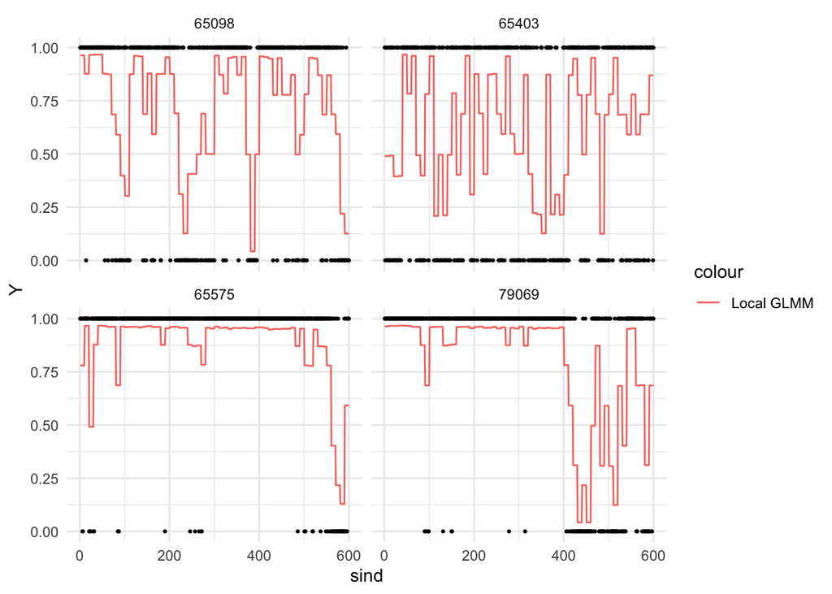

```r
df_est_latent %>%
  filter(id %in% sample(train_id, 4)) %>%
  ggplot()+
  geom_point(aes(x=sind, y=Y), size = 0.5)+
  geom_line(aes(x=sind, y=plogis(eta_hat), col = "Local GLMM"))+
  facet_wrap(~id)
```

# 2 Simulation using estimates from NHANES data

## 2.1 Estimates use for simualtion

For now I will use estimates from the model fit on the whole NHANES dataset, even though the spline basis is not proper (bs = “cc”).

```r
load(here("Data/Appl_debias_model.RData"))
J <- length(unique(df$sind))
n_bin <- J/bin_w # number of bins
brks <- seq(0, J, by = bin_w) # cutoff points
mid <- (brks+bin_w/2)[1:n_bin] # mid points

# eigenvalues
true_evals <- 1/debias_glmm$sp[2:5]/n_bin

# mean
# because of the parametrization of mgcv
# we need to add the constant intercept back
true_mu <- predict(debias_glmm, type = "terms")[1:J, 1]+coef(debias_glmm)[1]
# plot(1:J, true_mu)

# eigenfunctions
df_phi <- debias_glmm$model %>% select(sind, starts_with("phi")) %>% distinct(.) %>%
  mutate_at(vars(starts_with("phi")), function(x){x*sqrt(n_bin)})
```

Below are some visualizations of these estimates

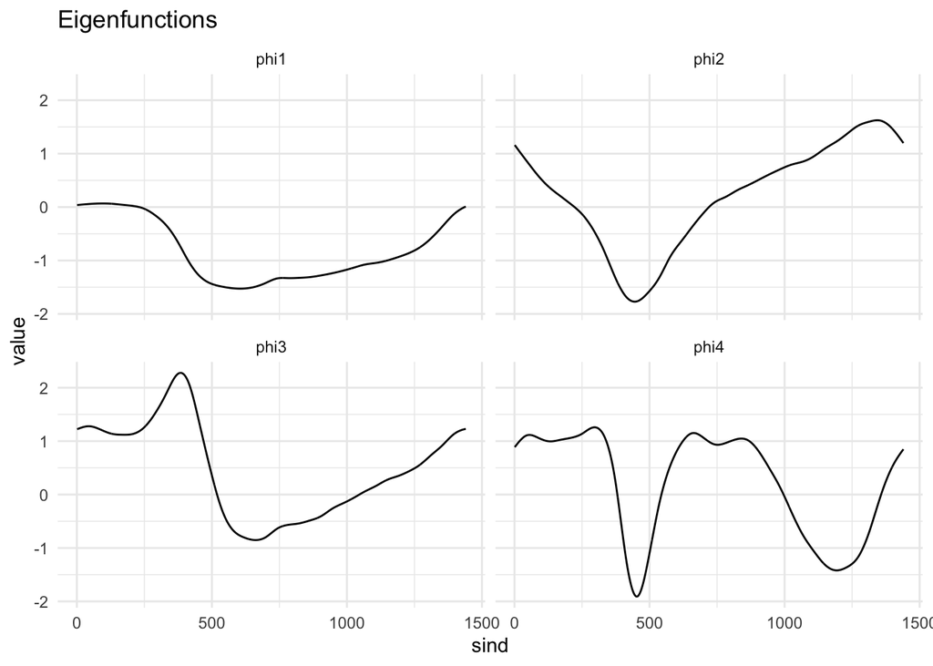

```r
df_phi %>%
  pivot_longer(starts_with("phi")) %>%
  ggplot()+
  geom_line(aes(x=sind, y=value))+
  facet_wrap(~name)+
  labs(title = "Eigenfunctions")
```

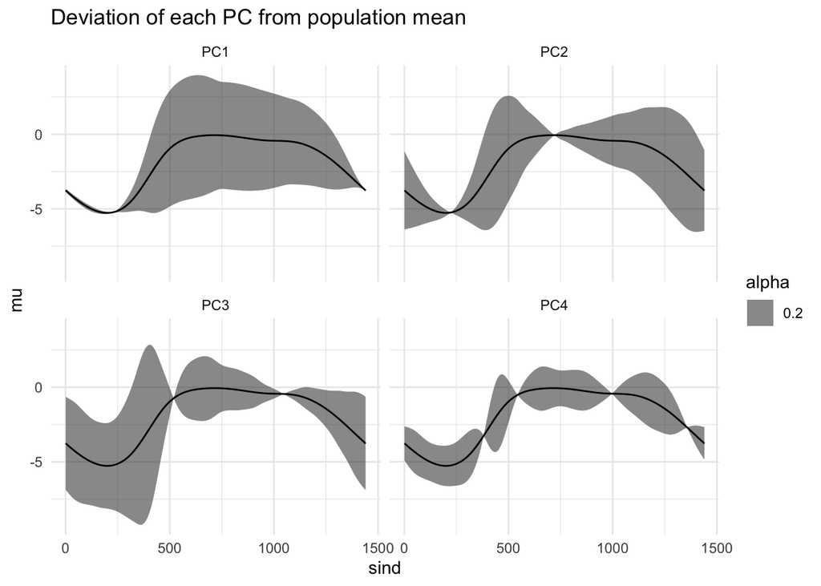

```r
df_pc_dev <- bind_rows(
  data.frame(sind = 1:J, mu=true_mu, pc = "PC1",
             high = true_mu + 2*sqrt(true_evals[1])*df_phi$phi1,
             low = true_mu - 2*sqrt(true_evals[1])*df_phi$phi1),
  data.frame(sind = 1:J, mu=true_mu, pc = "PC2",
             high = true_mu + 2*sqrt(true_evals[2])*df_phi$phi2,
             low = true_mu - 2*sqrt(true_evals[2])*df_phi$phi2),
  data.frame(sind = 1:J, mu=true_mu, pc = "PC3",
             high = true_mu + 2*sqrt(true_evals[3])*df_phi$phi3,
             low = true_mu - 2*sqrt(true_evals[3])*df_phi$phi3),
  data.frame(sind = 1:J, mu=true_mu, pc = "PC4",
             high = true_mu + 2*sqrt(true_evals[4])*df_phi$phi4,
             low = true_mu - 2*sqrt(true_evals[4])*df_phi$phi4)
)

# plot
df_pc_dev %>%
  ggplot()+
  geom_ribbon(aes(x=sind, y=mu, ymin=low, ymax=high, alpha = 0.2))+
  geom_line(aes(x=sind, y=mu))+
  facet_wrap(~pc)+
  labs(title = "Deviation of each PC from population mean")
```

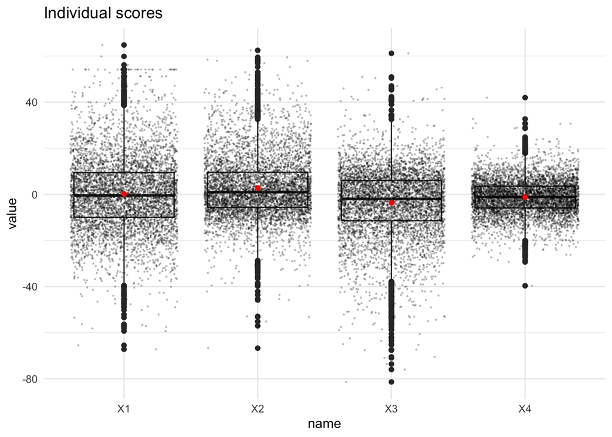

```r
data.frame(matrix(debias_glmm$coefficients[-c(1:9)], ncol = 4)) %>%
  pivot_longer(1:4) %>%
  ggplot(aes(x=name, y=value))+
  geom_boxplot()+
  geom_jitter(size = 0.2, alpha = 0.2)+
  stat_summary(fun=mean, geom="point", color="red")+
  labs(title = "Individual scores")
```

## 2.2 Simulation

Let’s repeat the simulation a few times:

- With different sample sizes
- With a lower-bounded mean

### 2.2.1 Sample size

```r
# increase sample size
Ntry_vec <- c(500, 1000, 1500, 2000)
data_list <- list()

for(n in seq_along(Ntry_vec)){

  Ntry <- Ntry_vec[n]

  # generate score
  xi <- rmvnorm(Ntry, mean = rep(0, K), sigma = diag(true_evals))

  # individual random effects
  bi <- as.matrix(df_phi[, 2:5]) %*% t(xi)

  # add in unbounded mean
  eta <- apply(bi, 2, function(x){x+true_mu})
  gen_df <- data.frame(id = factor(rep(1:Ntry, each=J)),
                       sind = rep(1:J, Ntry),
                       eta_i = as.vector(eta))

  # binary outcome
  gen_df$Y <- rbinom(Ntry*J, size=1, prob=plogis(gen_df$eta_i))

  data_list[[n]] <- gen_df

}
```

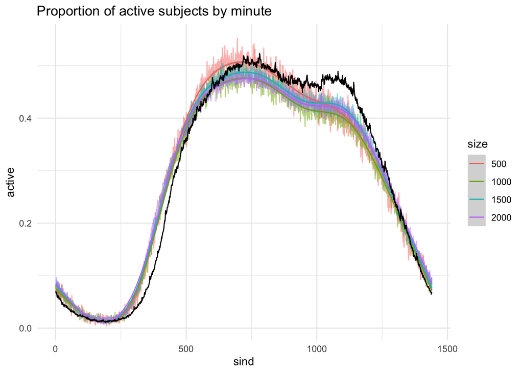

```r
data_list %>% bind_rows(.id = "size") %>%
  mutate(size = factor(size, levels = 1:length(Ntry_vec), labels = Ntry_vec)) %>%
  group_by(size, sind) %>%
  summarize(active = mean(Y)) %>%
  left_join(df %>% group_by(sind) %>% summarize(true_active = mean(Y)),
            by = "sind") %>%
  ggplot()+
  geom_line(aes(x=sind, y=active, col = size), alpha = 0.5)+
  geom_smooth(aes(x=sind, y=active, col = size), linewidth = 0.5)+
  geom_line(aes(x=sind, y=true_active), col = "black",
            linewidth=0.5)+
  labs(title="Proportion of active subjects by minute")
```

```r
# containers
time_vec <- rep(NA, length(Ntry_vec))
fpca_evals <- matrix(NA, nrow = length(Ntry_vec), ncol = K)
bam_evals <- matrix(NA, nrow = length(Ntry_vec), ncol = K)
```

```r
for(n in seq_along(Ntry_vec)){


  Ntry <- Ntry_vec[n]
  gen_df <- data_list[[n]]

  # bin data
  # using the same bin length
  gen_df$bin <- cut(gen_df$sind, breaks = brks, include.lowest = T, labels = mid)
  gen_df$bin <- as.numeric(as.character(gen_df$bin))

  # Step 2:  Local GLMM
  gen_bin_lst <- split(gen_df, f = gen_df$bin)
  df_est_latent <- lapply(gen_bin_lst, function(x){pred_latent(x, n_node = 0)})
  df_est_latent <- bind_rows(df_est_latent)

  # FPCA
  uni_eta_hat <- df_est_latent %>% filter(bin==sind)
  mat_est_unique <- matrix(uni_eta_hat$eta_hat,
                          nrow=Ntry,
                          ncol=n_bin, byrow = F)
  fpca_mod <- fpca.face(mat_est_unique, argvals = mid, var=T, npc=K) # keep 4 PCs

  # Re-evaluation
  est_phi <- matrix(NA, J, K)
  p <- 3 # order of b splines
  knots <- 35 # number of knots (same from FPCA model)
  knots_values <- seq(-p, knots + p, length = knots + 1 + 2 *p)/knots
  knots_values <- knots_values * (max(mid) - min(mid)) + min(mid)

  B <- spline.des(knots = knots_values, x = mid, ord = p + 1,
                  outer.ok = TRUE)$design  # evaluate B-splines on binned grid
  Bnew <- spline.des(knots = knots_values, x = 1:J, ord = p + 1,
                     outer.ok = TRUE)$design
  for(k in 1:K){
    lm_mod <- lm(fpca_mod$efunctions[,k] ~ B-1)
    est_phi[,k] <- Bnew %*% coef(lm_mod)
  }# project binned eigenfunctions onto the original grid

  ## debias
  est_phi <- data.frame(sind = 1:J, est_phi)
  colnames(est_phi) <- c("sind", paste0("phi", 1:K))
  gen_df <- gen_df %>% left_join(est_phi, by = "sind")
  gen_df$id <- as.factor(gen_df$id)

  ### model fit with B-splines basis
  t1 <- Sys.time()
  this_glmm <- bam(Y ~ s(sind, bs = "cr")+
                   s(id, by=phi1, bs="re")+
                   s(id, by=phi2, bs="re")+
                   s(id, by=phi3, bs="re")+
                   s(id, by=phi4, bs="re"),
                 family = binomial,
                 data=gen_df,
                 method = "fREML",
                 discrete = TRUE)
  t2 <- Sys.time()

  time_vec[n] <- t2-t1
  fpca_evals[n, ] <- fpca_mod$evalues
  bam_evals[n, ] <- 1/this_glmm$sp[2:5]/n_bin

}
```

- eigenvalues from FPCA

```r
# time_vec
data.frame(size = Ntry_vec, fpca_evals)
```

```
##   size       X1       X2       X3       X4
## 1  500 148.7312 76.94392 63.51343 20.06854
## 2 1000 136.3698 76.35706 66.16523 17.86043
## 3 1500 136.7598 71.77419 68.51804 19.45674
## 4 2000 135.4379 74.65509 65.97836 18.10959
```

- eigenvalues from BAM

```r
data.frame(size = Ntry_vec, bam_evals)
```

```
##   size       X1       X2       X3        X4
## 1  500 1.917435 1.128202 1.121289 0.3930604
## 2 1000 1.794443 1.160622 1.176021 0.3435035
## 3 1500 1.840956 1.147526 1.158084 0.3521302
## 4 2000 1.831116 1.157258 1.126806 0.3539690
```

- true eigenvalues used to generate data

```r
# true eigenvalues
true_evals
```

```
## s(id):phi1 s(id):phi2 s(id):phi3 s(id):phi4
##  1.8206755  1.2706966  1.6225247  0.4143347
```

## 2.3 Bounded mean

- Here, we put a lower bound to the mean function, so that the probablity of active status is greater than 0.2

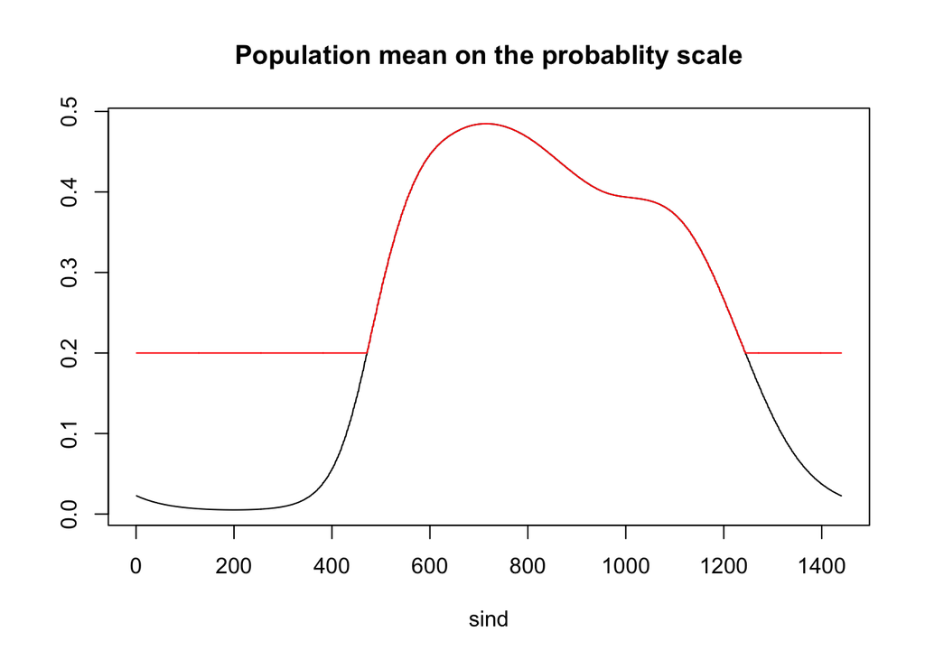

```r
bd_mean <- ifelse(plogis(true_mu)>=0.2, true_mu, logit(0.2))
plot(1:J, plogis(true_mu), type = "l", col = "black",
     main = "Population mean on the probablity scale",
     xlab = "sind", ylab = "")
lines(1:J, plogis(bd_mean), col = "red")
```

```r
# increase sample size
data_list_bdmean <- list()

for(n in seq_along(Ntry_vec)){

  Ntry <- Ntry_vec[n]

  # generate score
  xi <- rmvnorm(Ntry, mean = rep(0, K), sigma = diag(true_evals))

  # individual random effects
  bi <- as.matrix(df_phi[, 2:5]) %*% t(xi)

  # add in unbounded mean
  eta <- apply(bi, 2, function(x){x+bd_mean})
  gen_df <- data.frame(id = factor(rep(1:Ntry, each=J)),
                       sind = rep(1:J, Ntry),
                       eta_i = as.vector(eta))

  # binary outcome
  gen_df$Y <- rbinom(Ntry*J, size=1, prob=plogis(gen_df$eta_i))

  data_list_bdmean[[n]] <- gen_df

}
```

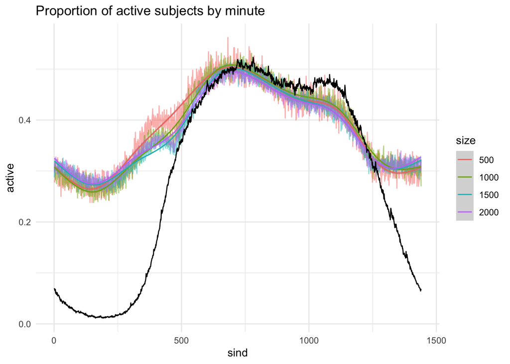

```r
data_list_bdmean %>% bind_rows(.id = "size") %>%
  mutate(size = factor(size, levels = 1:length(Ntry_vec), labels = Ntry_vec)) %>%
  group_by(size, sind) %>%
  summarize(active = mean(Y)) %>%
  left_join(df %>% group_by(sind) %>% summarize(true_active = mean(Y)),
            by = "sind") %>%
  ggplot()+
  geom_line(aes(x=sind, y=active, col = size), alpha = 0.5)+
  geom_smooth(aes(x=sind, y=active, col = size), linewidth = 0.5)+
  geom_line(aes(x=sind, y=true_active), col = "black",
            linewidth=0.5)+
  labs(title="Proportion of active subjects by minute")
```

```r
# containers
fpca_evals_bdmean <- matrix(NA, nrow = length(Ntry_vec), ncol = K)
bam_evals_bdmean <- matrix(NA, nrow = length(Ntry_vec), ncol = K)
```

```r
for(n in seq_along(Ntry_vec)){


  Ntry <- Ntry_vec[n]
  gen_df <- data_list_bdmean[[n]]

  # bin data
  # using the same bin length
  gen_df$bin <- cut(gen_df$sind, breaks = brks, include.lowest = T, labels = mid)
  gen_df$bin <- as.numeric(as.character(gen_df$bin))

  # Step 2:  Local GLMM
  gen_bin_lst <- split(gen_df, f = gen_df$bin)
  df_est_latent <- lapply(gen_bin_lst, function(x){pred_latent(x, n_node = 0)})
  df_est_latent <- bind_rows(df_est_latent)

  # FPCA
  uni_eta_hat <- df_est_latent %>% filter(bin==sind)
  mat_est_unique <- matrix(uni_eta_hat$eta_hat,
                          nrow=Ntry,
                          ncol=n_bin, byrow = F)
  fpca_mod <- fpca.face(mat_est_unique, argvals = mid, var=T, npc=K) # keep 4 PCs

  # Re-evaluation
  est_phi <- matrix(NA, J, K)
  p <- 3 # order of b splines
  knots <- 35 # number of knots (same from FPCA model)
  knots_values <- seq(-p, knots + p, length = knots + 1 + 2 *p)/knots
  knots_values <- knots_values * (max(mid) - min(mid)) + min(mid)

  B <- spline.des(knots = knots_values, x = mid, ord = p + 1,
                  outer.ok = TRUE)$design  # evaluate B-splines on binned grid
  Bnew <- spline.des(knots = knots_values, x = 1:J, ord = p + 1,
                     outer.ok = TRUE)$design
  for(k in 1:K){
    lm_mod <- lm(fpca_mod$efunctions[,k] ~ B-1)
    est_phi[,k] <- Bnew %*% coef(lm_mod)
  }# project binned eigenfunctions onto the original grid

  ## debias
  est_phi <- data.frame(sind = 1:J, est_phi)
  colnames(est_phi) <- c("sind", paste0("phi", 1:K))
  gen_df <- gen_df %>% left_join(est_phi, by = "sind")
  gen_df$id <- as.factor(gen_df$id)

  ### model fit with B-splines basis
  t1 <- Sys.time()
  this_glmm <- bam(Y ~ s(sind, bs = "cr")+
                   s(id, by=phi1, bs="re")+
                   s(id, by=phi2, bs="re")+
                   s(id, by=phi3, bs="re")+
                   s(id, by=phi4, bs="re"),
                 family = binomial,
                 data=gen_df,
                 method = "fREML",
                 discrete = TRUE)
  t2 <- Sys.time()

  # time_vec[n] <- t2-t1
  fpca_evals_bdmean[n, ] <- fpca_mod$evalues
  bam_evals_bdmean[n, ] <- 1/this_glmm$sp[2:5]/n_bin

}
```

- eigenvalues from FPCA

```r
# time_vec
data.frame(size = Ntry_vec, fpca_evals_bdmean)
```

```
##   size       X1       X2       X3       X4
## 1  500 133.4727 108.2285 86.14238 29.62960
## 2 1000 147.7269 111.2194 84.18844 26.59217
## 3 1500 135.6999 103.6076 83.55268 28.43754
## 4 2000 140.4168 104.4160 88.24528 29.06756
```

- eigenvalues from BAM

```r
data.frame(size = Ntry_vec, bam_evals_bdmean)
```

```
##   size       X1       X2       X3        X4
## 1  500 1.801938 1.473830 1.197275 0.4165208
## 2 1000 1.877590 1.567811 1.143567 0.3808318
## 3 1500 1.835916 1.499466 1.163188 0.4076724
## 4 2000 1.850525 1.465430 1.183478 0.4139039
```